### 8월/5주

#### ▶ ▣ 정당지지도 ▣

더불어민주당 45.6%, 국민의힘 35.1%, 정의당 1.9%, 기타 정당 3.4%, 지지하는 정당이 없다 13.4%, 잘 모르겠다 0.7%

#### ▶ ▣ 대통령 국정 수행 평가 ▣

잘하고 있다 38.1%, 잘못하고 있다 60.3%, 잘 모르겠다 1.6%

#### ☑ ▣ 내년 총선 지지 방향 ▣

원활한 국정수행을 뒷받침하기 위해 여당인 국민의힘에 힘을 실어 줘야 한다 35.3%, 현 정권 견제를 위해서 제1야당인 민주당에 힘을 실어 줘야 한다 48.9%, 기존 양당이 아닌 제3세력에 힘을 실어 줘야 한다 15.8%

#### ☑ ▣ 후쿠시마 오염수 방류 정부 대응 적절성 ▣

매우 적절하다 20.7%, 어느 정도 적절하다 16.0%, 별로 적절하지 않다 7.6%, 전혀 적절하지 않다 54.4%, 잘 모르겠다 1.3%

#### ☑ ▣ 정기 국회 의정활동 전망 ▣

매우 잘못할 것이다 42.1%, 어느 정도 잘못할 것이다 27.7%, 어느 정도 잘할 것이다 16.4%, 잘 모르겠다 7.1%, 매우 잘할 것이다 6.7%

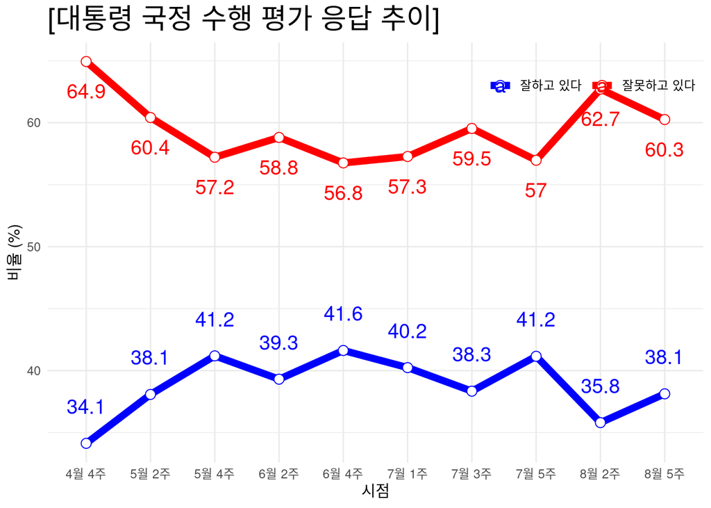

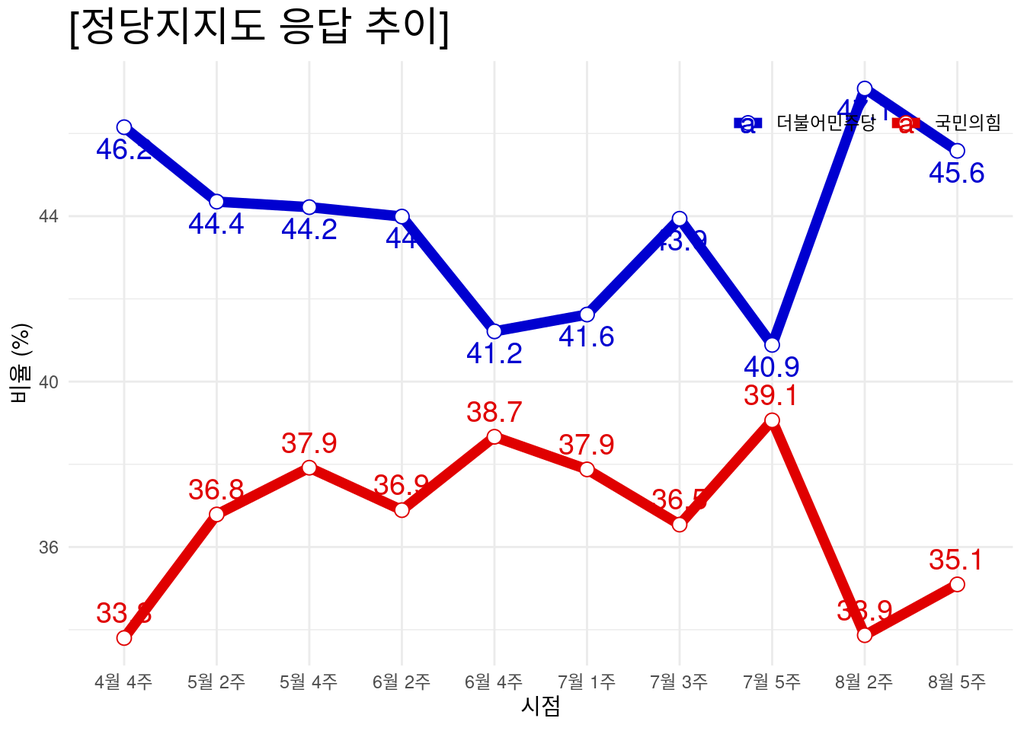

### 추가사항

- [주요질문 / 집단별 세부통계 보기](https://modernity.shinyapps.io/survey_str/) (링크누르시오)

### 참고사항

- 표본수: 2,018명,표본오차는 95% ±2.2%p
- 조사정보: 스트레이트뉴스의 의뢰로 조원씨앤아이가 2023년 8월 26~28일 3일간

  전국 만 18세 이상 남녀를 대상으로 ARS 여론조사

  (휴대전화 100% RDD 방식, 성,연령대,지역별 비례할당 무작위 추출)를 실시한 결과이며,

  표본수는 2,018(총 통화시도 78,375명, 응답률 2.6%)

  ※ 가중치 부여 방식: [림가중] 성별, 연령별, 지역별 가중값 부여(2023년 7월말 행정안전부 발표 주민등록인구기준)
- [중앙선거여론조사심의위원회](https://nesdc.go.kr/portal/bbs/B0000005/list.do?menuNo=200467)에서 관련사항 확인가능

2023.08.30 (수) 08:05 제작

- 연구개발 단계입니다.
- 제공: 감동과 마음의 [조원씨앤아이](http://jowoncni.com/html/index.html)